# Taller Clusters

Johan Ayala y Daniel Mayor

6/4/2022

La base de datos que se va a tratar corresponde a las 2000 empresas más grandes del mundo, con ellas se tienen diferentes variables que pueden ayudar a la segmentacion de estas en grupos, tales variables como el pais, el valor de la empresa, los ingresos,las ventas, los activos se presentan en la siguiente base.

### Carga de la base de datos

```r
base=read.csv("C:\\Users\\jsaj_\\Downloads\\FG2000_2017.csv",sep=';')
```

### Carga de las librerias

```r
library(readxl)
library(MASS)
library(mclust)
library(fpc)
library(factoextra)
library(dplyr)
```

Principales caracteristicas de la base

```r
rownames(base)<-base$Company.Name
any(is.na(base))
```

```
## [1] TRUE
```

```r
nrow(base)  # numero de individuos
```

```
## [1] 2000
```

```r
ncol(base) # numero de columnas
```

```
## [1] 7
```

```r
summary(base)
```

```
##       Rank        Company.Name         Country              Sales
##  Min.   :   1.0   Length:2000        Length:2000        Min.   :  0.001
##  1st Qu.: 500.8   Class :character   Class :character   1st Qu.:  4.000
##  Median :1000.5   Mode  :character   Mode  :character   Median :  8.800
##  Mean   :1000.5                                         Mean   : 17.681
##  3rd Qu.:1500.2                                         3rd Qu.: 17.475
##  Max.   :2000.0                                         Max.   :485.300
##                                                         NA's   :2
##     Profits             Assets             Value
##  Min.   :-13.0000   Min.   :   0.001   Min.   :  0.072
##  1st Qu.:  0.3180   1st Qu.:  10.900   1st Qu.:  6.600
##  Median :  0.6125   Median :  22.900   Median : 11.900
##  Mean   :  1.2412   Mean   :  84.571   Mean   : 24.423
##  3rd Qu.:  1.3000   3rd Qu.:  52.400   3rd Qu.: 24.400
##  Max.   : 45.2000   Max.   :3473.200   Max.   :752.000
##                     NA's   :1          NA's   :1
```

### Tratamiento de datos

```r
base[is.na(base)] <- 0
base <-base%>%mutate(Country=as.numeric(as.factor(base$Country)))
base=base%>%select('Country','Sales','Profits','Assets','Value')
```

### Revision de las relaciones que existen

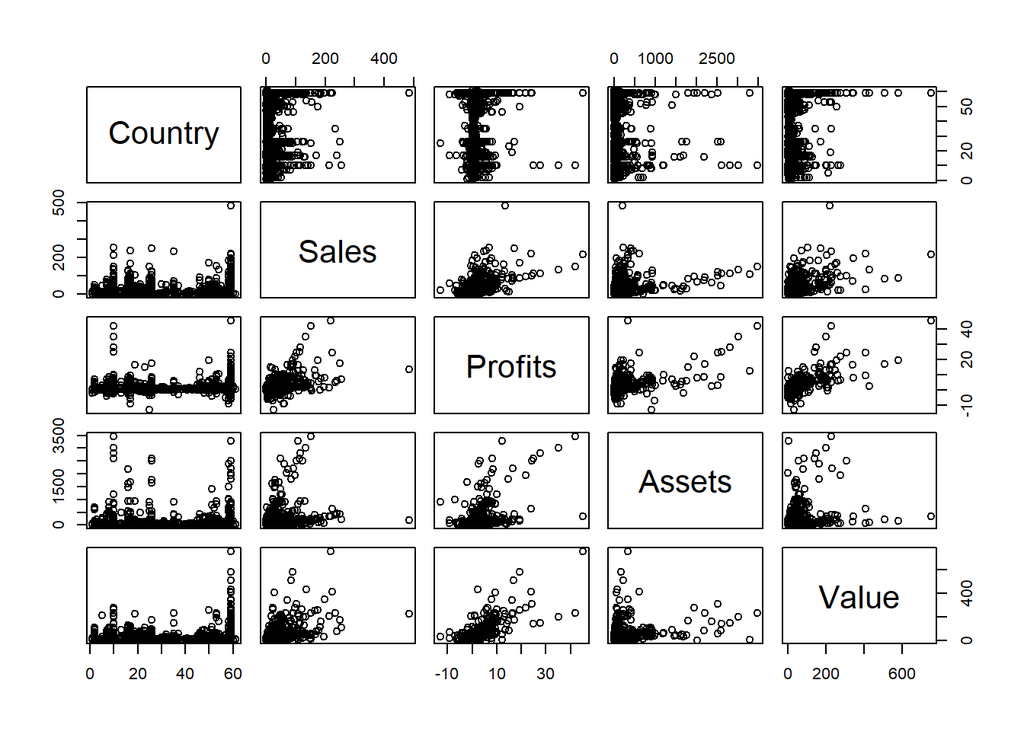

```r
pairs(base)
```

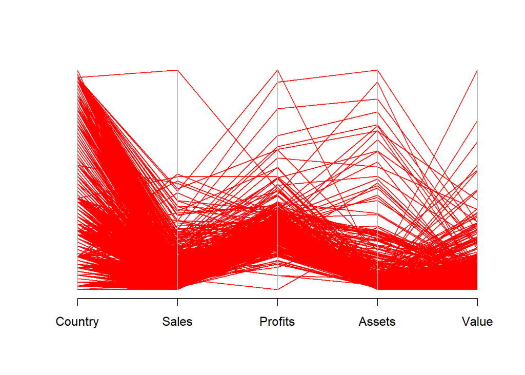

```r
parcoord(base, cex.axis = 1.4, col = "red")
```

Encontramos que no hay una correlacion significativa entre las variables, apenas solo en la variable profits con assets y value, son las correlaciones que presentan una leve tendencia positiva, pero no concluyente. Para revisar el Parcoord, vemos como es el comportamiento de las variables Country, Sales,Profits,Assets y Value. donde se tiene una clara tendencia en muchos valores a excepcion de puntos que se comportan de manera diferente, pero en general tiene la misma tendencia.

### Calcular las distancias por manhattan

```r
dm.m  <- dist(x = base, method = "manhattan")
round(as.matrix(dm.m)[1:5, 1:5], 2)
```

```
##                           ICBC China Construction Bank Berkshire Hathaway
## ICBC                       0.0                   510.1             3170.8
## China Construction Bank  510.1                     0.0             2753.7
## Berkshire Hathaway      3170.8                  2753.7                0.0
## JPMorgan Chase          1152.7                   701.2             2115.9
## Wells Fargo             1697.3                  1245.8             1585.5
##                         JPMorgan Chase Wells Fargo
## ICBC                            1152.7      1697.3
## China Construction Bank          701.2      1245.8
## Berkshire Hathaway              2115.9      1585.5
## JPMorgan Chase                     0.0       609.0
## Wells Fargo                      609.0         0.0
```

### Encontrar el mejor metodo para realizar los clusters

```r
fit_sing <- hclust(d = dm.m, method = "single")
fit_aver <- hclust(d = dm.m, method = "average")
fit_comp <- hclust(d = dm.m, method = "complete")
fit_ward <- hclust(d = dm.m, method = "ward.D")
cor.s = cor(x = dm.m, cophenetic(fit_sing))
cor.a = cor(x = dm.m, cophenetic(fit_aver))
cor.c = cor(x = dm.m, cophenetic(fit_comp))
cor.w = cor(x = dm.m, cophenetic(fit_ward))
Resul = c(cor.s, cor.a, cor.c, cor.w)
names(Resul) = c("single", "average", "complete", "ward.D")
Resul
```

```
##    single   average  complete    ward.D
## 0.9254467 0.9475385 0.9267382 0.6786375
```

Con lo anterior elegimos a linkage average porque es el que da la mayor correlacion

### Grafica para eleccion de Clusters

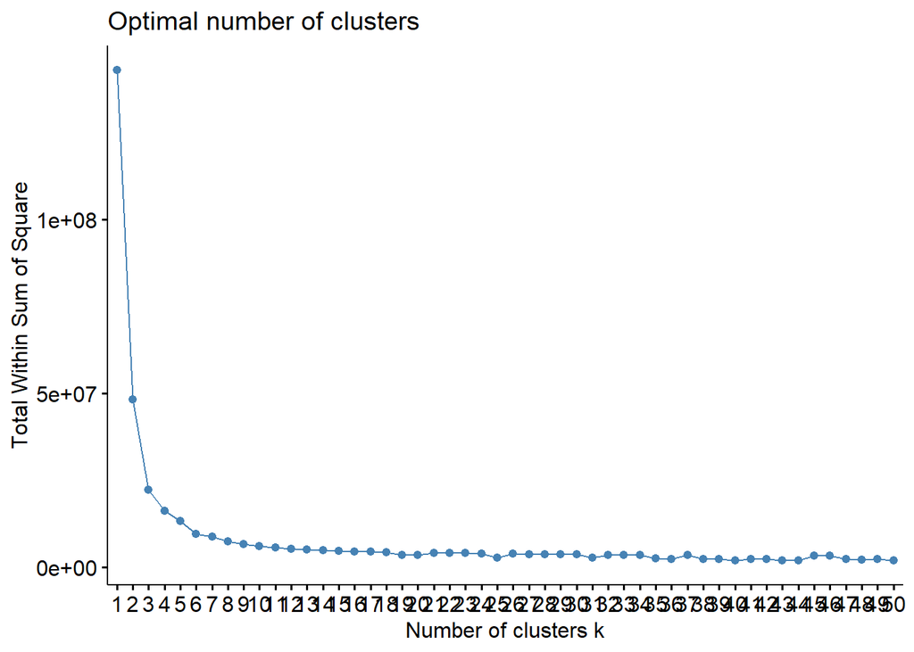

```r
fviz_nbclust(x = base, FUNcluster = kmeans,
             method = "wss", k.max = 50, nstart = 100)
```

Se toman por lo tanto 6 Clusters

```r
cluster <- cutree(fit_aver, k = 6)
table(cluster)
```

```
## cluster
##    1    2    3    4    5    6
##    4    4    7   10 1919   56
```

```r
lista = c()
for (a in 1:2000){
  lista=c(lista,a)

}

### Dividir por clusters
division=data.frame(rownames(base),cluster,row.names =lista)
agrupados=split(division,division$cluster)
agrupados[1]
```

```
## $`1`
##                 rownames.base. cluster
## 1                         ICBC       1
## 2      China Construction Bank       1
## 6   Agricultural Bank of China       1
## 342                 Fannie Mae       1
```

```r
agrupados[2]
```

```
## $`2`
##        rownames.base. cluster
## 3  Berkshire Hathaway       2
## 9               Apple       2
## 19          Microsoft       2
## 24           Alphabet       2
```

### Usando componentes prinicpales

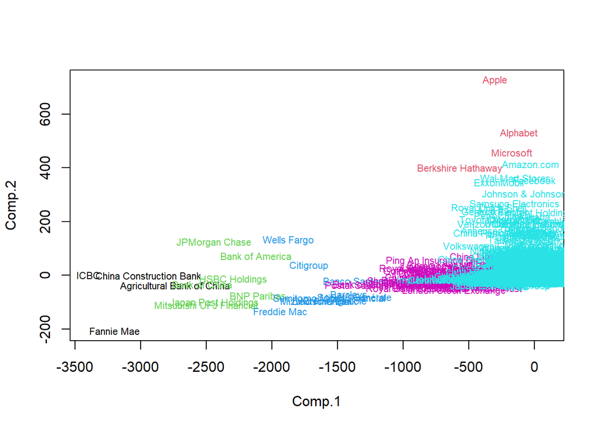

```r
pc   <- princomp(base)
labs <- cutree(fit_aver, k = 6)
plot(pc$scores[ , 1:2], type = "n")
text(pc$scores[ , 1:2], labels = rownames(base),
     col = labs, cex = 0.7)
```

Podemos ver como hay 6 grupos donde estan marcadas las diferencias, en un lado tenemos los grandes de la industria en Rojo y arriba, en la otra esquina a empresas estatales chinas en negro, el grupo verde se caracteriza por ser grandes bancos y el azul bancos pero no con diferentes niveles a los primeros y luego otros dos grupos que no se diferencian entre si, siendo el grupo de la esquina inferior derecha el que concentra todos.

### Representacion grafica

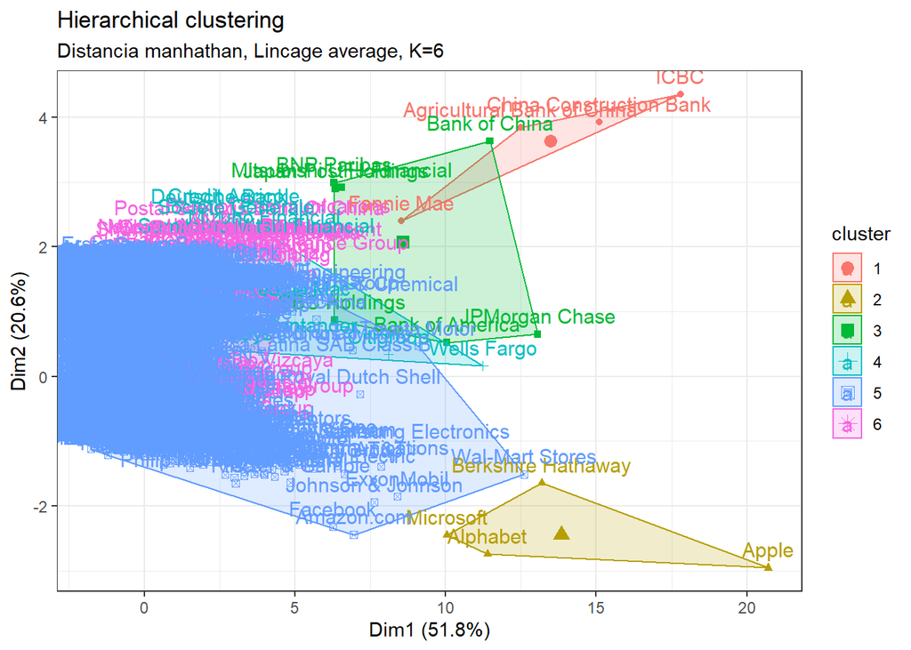

```r
fviz_cluster(list(data = base, cluster = cluster),
             ellipse.type = "convex") +
  labs(title = "Hierarchical clustering",
       subtitle = "Distancia manhathan, Lincage average, K=6") +
  theme(legend.position = "bottom") + theme_bw()
```

### Normalizando los datos

```r
rge <- sapply(base, function(x) diff(range(x)))
X   <- sweep(x = base, MARGIN = 2, STATS = rge, FUN = "/")
sapply(X, var)
```

```
##     Country       Sales     Profits      Assets       Value
## 0.114705422 0.003650351 0.002514412 0.005646442 0.003543453
```

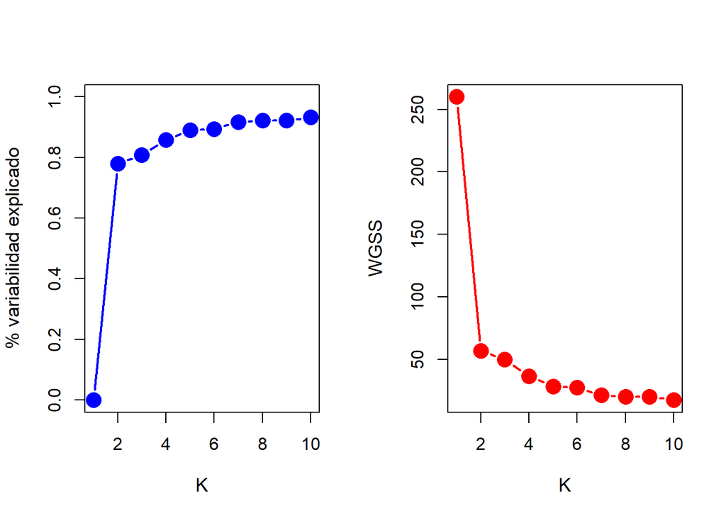

```r
pctp   <- 0
within <- kmeans(x = X, centers = 1)$totss
for (k in 2:10) {
  clk    <- kmeans(X, centers = k)
  # ajustar clustering de k medias
  wi     <- sum(clk$withinss) # WGSS
  #withinss: Vector de suma de cuadrados dentro de un grupo, un componente por grupo.
  pcte   <- clk$betweenss / clk$totss
  # betweenss: La suma de cuadrados entre grupos
  pctp   <- c(pctp, pcte)
  within <- c(within, wi)
  # % de variabilidad explicado
}
par(mfrow = c(1, 2))
plot(pctp, type = "b", pch = 16, cex = 2, cex.lab = 1.1, lwd = 2, ylim = c(0,1),
     col = "blue",xlab = "K", ylab = "% variabilidad explicado")
plot(within, type = "b", pch = 16, cex = 2, cex.lab = 1.1, lwd = 2,
     col = "red",xlab = "K", ylab = "WGSS")
```

### Graficos Normalizados

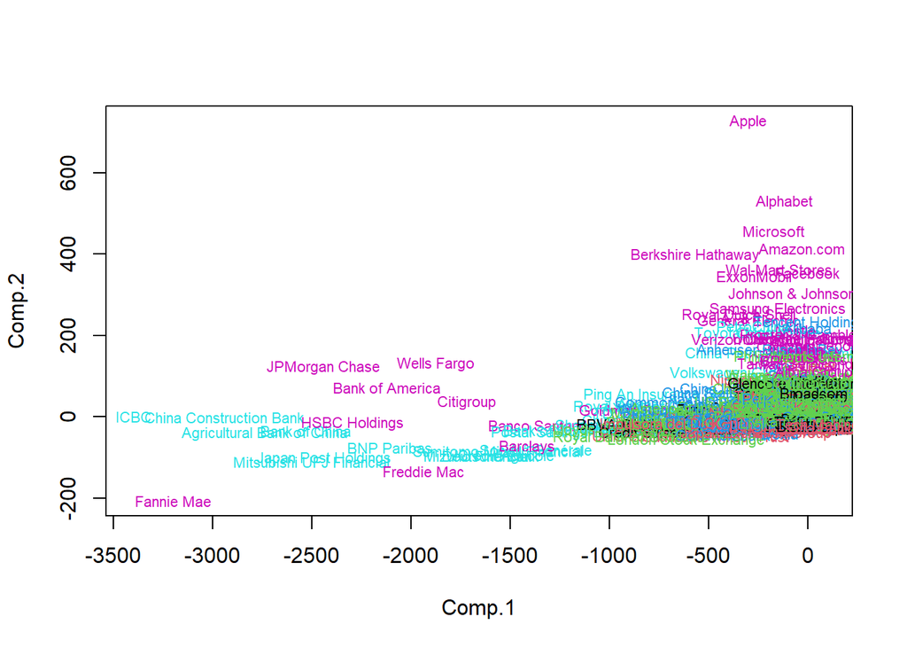

```r
pc   <- princomp(base)
# componentes principales
labs <- kmeans(X, centers = 6)$cluster


par(mfrow = c(1, 1))
# Gráficos
plot(pc$scores[ , 1:2], type = "n")
text(pc$scores[ , 1:2], labels = rownames(base), col = labs, cex = 0.7)
```

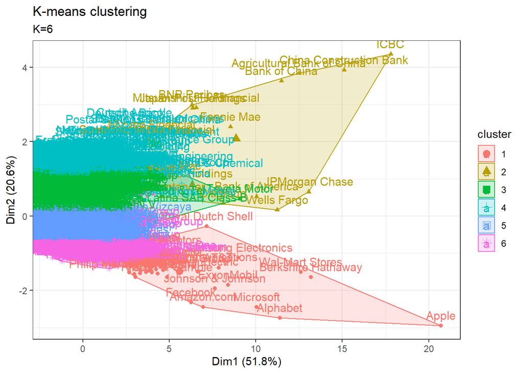

```r
##############
fit_kmean = kmeans(x = X, centers = 6, nstart = 50)

fviz_cluster(list(data = base, cluster = fit_kmean$cluster),
             ellipse.type = "convex") +
  labs(title = "K-means clustering",
       subtitle = "K=6") +
  theme(legend.position = "bottom") + theme_bw()
```

### Revision final

Dispersograma con los clusters formados

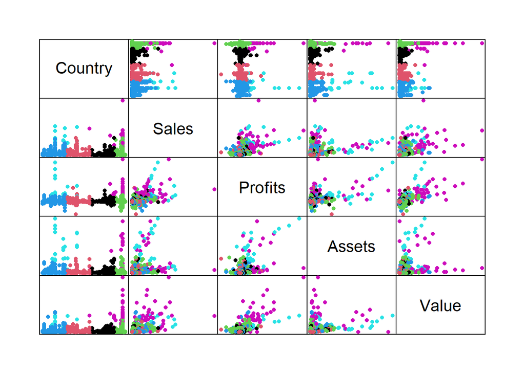

```r
pairs(X, pch = 16, gap = 0, xaxt = "n", yaxt = "n", col = labs)
```